# NMC_Final Report

```r
library(ggplot2)
library(grid)
library(gridExtra)
library(tidyr)
library(dplyr)
library(viridis)
library(gtools)
library(RColorBrewer)
```

```r
d=data.frame(x1=c(1914,1939, 1947, 1950, 1955, 2001), x2=c(1918, 1945, 1991, 1953, 1975, 2010), Conflict=c("WWI", "WWII", "Cold War", "Korean War", "Vietnam War", "Afghanistan War"), r=c(1,2,3,4,5,6))
member_alliances = read.csv("./data/version4.1_csv/alliance_v4.1_by_member.csv", sep= ",")
NMC_orig = read.csv("./data/NMC/NMC_v4_0.csv", sep= ",")
NMC <- NMC_orig
NMC$cinc[NMC$cinc == -9| is.na(NMC$cinc)] <- 0
NMC$irst[NMC$irst == -9| is.na(NMC$irst)] <- 0
NMC$milex[NMC$milex == -9| is.na(NMC$milex)] <- 0
NMC$milper[NMC$milper== -9| is.na(NMC$milper)] <- 0
NMC$pec[NMC$pec == -9| is.na(NMC$pec)] <- 0
NMC$tpop[NMC$tpop == -9| is.na(NMC$tpop)] <- 0
NMC$upop[NMC$upop == -9| is.na(NMC$upop)] <- 0
all_year <- c(1900:2007)
NMC_ratios <- c("")
for (year_t in all_year){
  yr <- filter(NMC, NMC$year %in% year_t)
  max <- apply(yr[, c(4:9)], 2, sum)
  #max <- as.numeric(max[4:9])
  for (i in 4:9){
    yr[,i] = as.numeric(yr[,i]/max[i-3])
  }
  NMC_ratios <- smartbind(NMC_ratios , yr)
}
NMC_ratios  <- NMC_ratios [c(2:nrow(NMC_ratios )), c(2:length(NMC_ratios))]
cbbPalette <- c("#000000", "#E69F00", "#56B4E9", "#009E73", "#F0E442", "#0072B2", "#D55E00", "#CC79A7")
```

National Materials Capability measures the power of a country based on 6 values: total population, urban population, military personnel, military expenditures, iron and steel production and energy consumption. NMC is purely a measure of military and economic means of influence rather than diplomacy or other forms of influence.

Below is the CNIC score for major powers today who also participated the major wars in the past. Also highlighted are the years wars mentioned above.

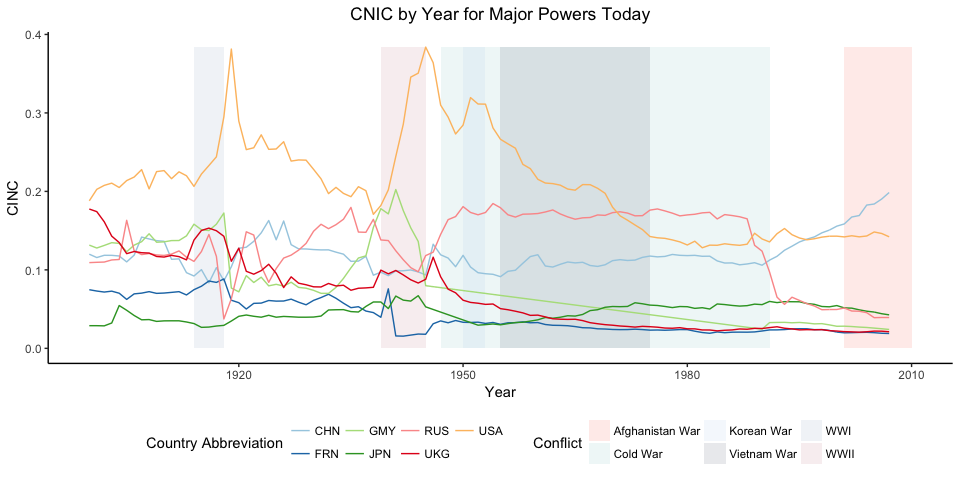

```r
countries <- c("United States of America", "United Kingdom", "France", "Russia","Germany", "Japan", "China")
country_code <- member_alliances$ccode[match(countries, member_alliances$state_name)]
NMC_mp <- filter(NMC, NMC$year %in% all_year)
NMC_mp <- filter(NMC_mp, NMC_mp$ccode %in% country_code)
ggplot() +
  scale_x_continuous(name="Year") +
  scale_y_continuous(name="CINC") +
  labs(color ='Country Abbreviation')+
  geom_rect(data=d, mapping=aes(xmin=x1, xmax=x2, ymin=0, ymax=max(NMC_mp$cinc), fill=Conflict),alpha=0.15) +
  geom_line(data = NMC_mp, aes(x = year, y = cinc, color = stateabb, group = stateabb)) +
  ggtitle("CNIC by Year for Major Powers Today") +
  theme_classic()+
  scale_fill_manual(values=c("salmon", "paleturquoise3", "lightsteelblue2", "lightsteelblue4", "lightsteelblue3", "pink3"))+
  scale_color_brewer(palette="Paired")+
  theme(plot.title = element_text(hjust = .5), legend.position = "bottom")
```

```r
NA
```

As you can see CNIC is changing year by year. What is interesting is that the CNIC spikes for the US right after WWI and WWII where the US had a major role in the outcome of the wars. At the end of WWI, you see Russia’s CNIC dip low but it bounced back to its CNIC before WWI pretty quickly. To explore the trends more, the data was refined to only look at the major participants of each war. For example, with WWI we looked at the CINC values for major players in the Allied Powers and Central Powers a few years before and after the war. We replicated this process for all the events listed above. Below are CINC graphs using this approach for WWI and WWII.

```r
allied <- c("United States of America", "United Kingdom", "Russia", "Japan", "Italy")
allied_ccode <- member_alliances$ccode[match(allied, member_alliances$state_name)]
central <- c("Germany", "Turkey", "Austria-Hungary", "Romania", "Bulgaria")
central_ccode <- member_alliances$ccode[match(central, member_alliances$state_name)]
WWI_range = c(1904:1930)
WWI<- filter(NMC, NMC$year %in% WWI_range)
alliedP<- filter(WWI, WWI$ccode %in% allied_ccode)
alliedP$side = "Allied Powers"
centralP<- filter(WWI, WWI$ccode %in% central_ccode)
centralP$side = "Central Powers "
WWI <-rbind(alliedP, centralP)
ww1 <- ggplot() +
  labs(color ='Country Abbreviation')+
  xlab("Year") +
  ylab("CNIC")+
  geom_rect(data=d, mapping=aes(xmin=1914, xmax=1918, ymin=0, ymax=.4),alpha=0.05, fill ="salmon") +
  geom_line(data = WWI, aes(x = year, y = cinc, color = stateabb, group = stateabb)) +
  facet_wrap(~side) +
  theme_classic()+
  scale_color_brewer(palette="Paired")+
  ggtitle("CNIC Score: WWI Major Players ")+
   theme(plot.title = element_text(hjust = .5),legend.position="right")
allies <- c("United States of America", "United Kingdom", "France", "Russia", "Australia", "Belgium","China", "Denmark", "Greece", "Netherlands")
allies_ccode <- member_alliances$ccode[match(allies, member_alliances$state_name)]
axis <- c("Germany", "Italy", "Japan", "Hungary", "Romania", "Bulgaria")
axis_ccode <- member_alliances$ccode[match(axis, member_alliances$state_name)]
WWII_range = c(1934:1950)
WWII<- filter(NMC, NMC$year %in% WWII_range)
alliedP<- filter(WWII, WWII$ccode %in% allied_ccode)
alliedP$side = "Allies"
axisP<- filter(WWII, WWII$ccode %in% axis_ccode)
axisP$side = "Axis"
WWII <-rbind(alliedP, axisP)
ww2 <- ggplot() +
  labs(color ='Country Abbreviation')+
  xlab("Year") +
  ylab("CNIC")+
  geom_rect(data=d, mapping=aes(xmin=1939, xmax=1945, ymin=0, ymax=.4),alpha=0.05, fill ="paleturquoise3") +
  geom_line(data = WWII, aes(x = year, y = cinc, color = stateabb, group = stateabb)) +
  facet_wrap(~side) +
  theme_classic()+
  scale_color_brewer(palette="Paired")+
  ggtitle("CNIC Score: WWII Major Players ")+
  theme(plot.title = element_text(hjust = .5),legend.position="right")
```

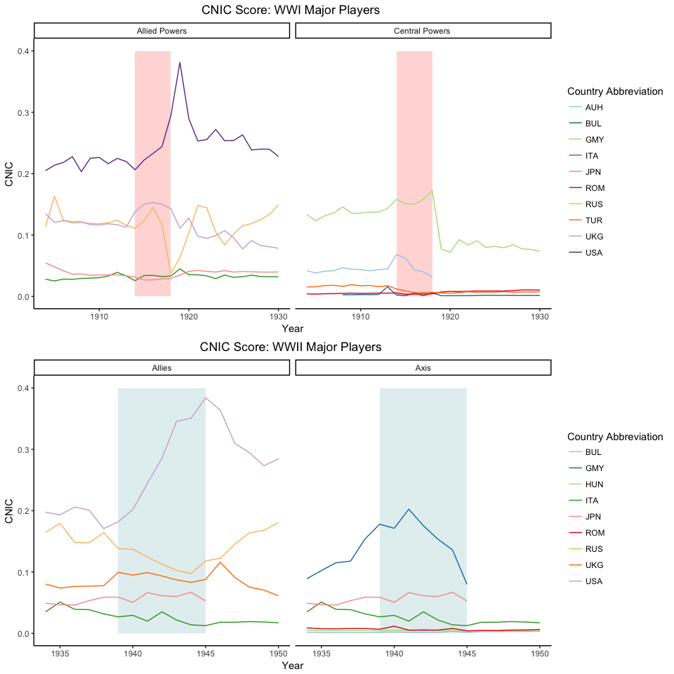

```r
grid.arrange(ww1, ww2, nrow=2)
```

As mentioned, with WWI the US’s CINC spiked right after the war and then began to steadily decrease till the beginning of the WWII. Russia’s CINC dropped but rose again pretty quickly and stayed on a relatively upward trend till WWII. Unlike the US and Russia, United Kingdom’s CINC was steadily decreasing after the war. Italy and Japan’s CINC remained steady. With the Central Powers after WWI, Germany’s CINC dropped but it did not rise again. Turkey’s, Romania’s and Bulgaria’s CINC remained steady. We see the Austria-Hungarian CINC disappear after the war since the Austro-Hungarian empire was dissolved at the end of the war.

With WWII, we see a similar pattern for the US where the CNIC reaches a peak at the end of WWII and steadily decreases till the Korean war. Russia also shows a similar pattern to WWI where its CINC score reaches a low point towards the end of WWII and then continues to steadily increase till the Korean war. The UK also follows a similar pattern where it CINC peaks right after the war and then steadily decreases throughout the Cold War time period. With the Axis powers, Germany’s and Japan’s CINC drops off.

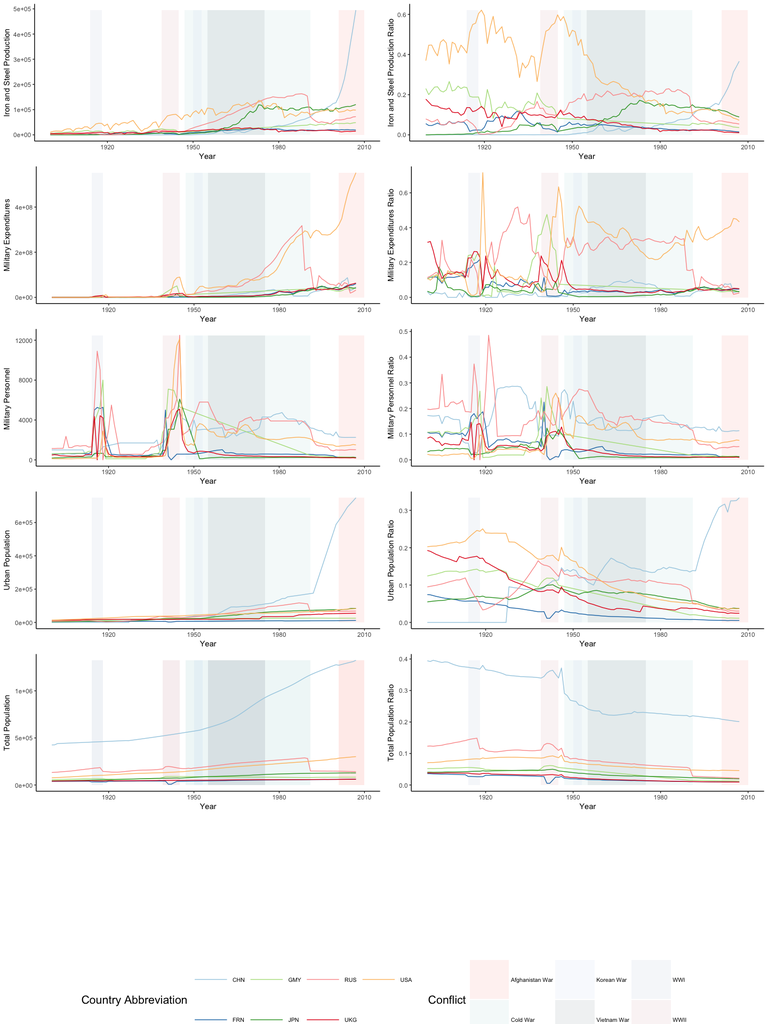

```r
grid.arrange(arrangeGrob(ias, ias_r, mex, mex_r, mip, mip_r, urp, urp_r, top, top_r + theme(plot.title = element_text(hjust = .5), legend.position="none"),nrow=6, ncol =2),mylegend, heights=c(10,1/2))
```

```r
#grid.arrange(ias, ias_r, mex, mex_r, mip, mip_r, urp, urp_r, top, top_r, nrow=6)
```

We looked at both the ratio in addition to the actual value because the all the values gradually increased over time but the ratios show performance relative to the other countries.

With the Iron and Steel Production ratio, you can see that it follows to same pattern for the US and its CINC during this time period with peaks after the war and decreasing till the next war. Till about the beginning of the Vietnam War, roughly 1955, the US dominated the world in Iron and Steel production and so this value had huge impact the US’s CINC score. Generally, during most wars, the US has the most military production

Heat Map

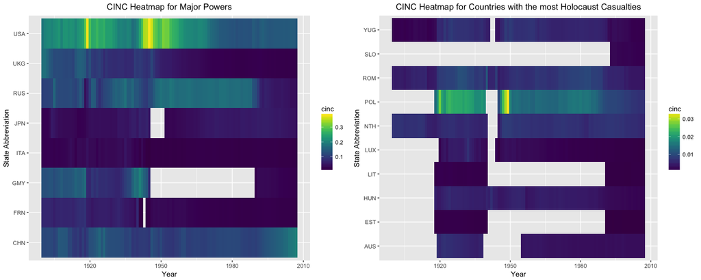

```r
ct <- c("United States of America", "United Kingdom", "France", "Russia","Germany", "Italy", "Japan", "China")
ct_ccode <- member_alliances$ccode[match(ct, member_alliances$state_name)]
NMC_ct <- filter(NMC, NMC$year %in% all_year)
NMC_ct <- filter(NMC_ct, NMC_ct$ccode %in% ct_ccode)
a<- ggplot(NMC_ct, aes(stateabb, year, fill = cinc)) + geom_tile()+
   xlab("State Abbreviation") +
   ylab("Year") +
  scale_fill_viridis() + ggtitle("CINC Heatmap for Major Powers") + theme(plot.title = element_text(hjust = 0.5)) +coord_flip() +
  labs(color ='CINC')
topCas <- c("Netherlands", "Yugoslavia", "Lithuania", "Poland", "Austria", "Hungary", "Slovakia", "Romania", "Estonia", "Luxembourg")
topCas_ccode <- member_alliances$ccode[match(topCas, member_alliances$state_name)]
NMC_cas <- filter(NMC, NMC$year %in% all_year)
NMC_cas <- filter(NMC_cas, NMC_cas$ccode %in% topCas_ccode)
b<- ggplot(NMC_cas, aes(stateabb, year, fill = cinc)) + geom_tile()+
   xlab("State Abbreviation") +
   ylab("Year") +
  scale_fill_viridis() + ggtitle("CINC Heatmap for Countries with the most Holocaust Casualties") + theme(plot.title = element_text(hjust = 0.5)) +coord_flip() +
  labs(color ='CINC')
grid.arrange(a,b, nrow = 1 )
```

**Next Steps**

To get even more into detail and context around certain characteristics, we want to look at specific events like pearl harbor or China’s invasion of Malaysia and other pivotal moments in wars to see how those events impact the CINC and its various components.

A problem with NMC is that there are many other factors that determine a power of a nation rather than the 6 NMC factors. One of the major considerations that is not taken into account are diplomatic relations and dealings. Diplomatic relations play a major role is the prevention and conclusion of conflicts. With this data, it was not possible to factor that in.

Additionally, another thing to consider is differences in policies between different countries. We see that military expenditures have been increasing for the US since the Cold War but Russia’s military expenditures take a sudden drop at the end of the Cold War. Since then Russia has been cutting military spending till today. Even with its participation in the Afghanistan War, Russia’s military expenditures have not increase. On the contrary, in the US today, politicians are proposing a Federal Budgets with increases in military spending. This difference is due to differences in policies of the countries. Thus the reactions of countries to events will drastically vary based on their policies and it because hard to distinguish an overall pattern.

Another drawback of NMC is that it cannot take into account changes in universal priorities. For example, with an increased concern for climate change and scare natural resources, iron and steel production might start to decrease drastically in the future so it may no longer be a valid measure of power. The issue with NMC is that it cannot take such policy concerns and changes into consideration to measure national power.

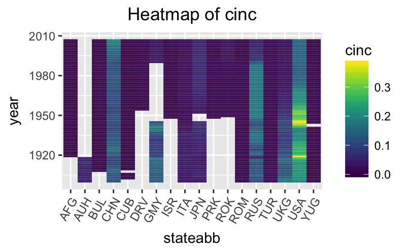

```r
ct <- c("United States of America", "United Kingdom", "Russia", "Japan", "Italy", "Germany", "Turkey", "Austria-Hungary", "Romania", "Bulgaria", "Vietnam", "Afghanistan", "Israel", "China", "Cuba", "North Korea", "South Korea", "Yugoslavia")
ct_ccode <- member_alliances$ccode[match(ct, member_alliances$state_name)]
NMC_ct <- filter(NMC, NMC$year %in% all_year)
NMC_ct <- filter(NMC_ct, NMC_ct$ccode %in% ct_ccode)
ggplot(NMC_ct, aes(stateabb, year, fill = cinc)) + geom_tile()+
  scale_fill_viridis() + ggtitle("Heatmap of cinc") + theme(axis.text.x = element_text(angle = 60, hjust = 1),plot.title = element_text(hjust = 0.5))
```

# Ignore Anything below this

```r
NMC_mp_ratios$conflict <- "0"
for(i in c(1:length(d$x1))){
  print(d$Conflict[i])
  NMC_mp_ratios[NMC_mp_ratios$year >= d$x1[i] & NMC_mp_ratios$year <= d$x2[i],12] <- as.character(i)
}
```

```
[1] WWI
Levels: Afghanistan War Cold War Korean War Vietnam War WWI WWII
[1] WWII
Levels: Afghanistan War Cold War Korean War Vietnam War WWI WWII
[1] Cold War
Levels: Afghanistan War Cold War Korean War Vietnam War WWI WWII
[1] Korean War
Levels: Afghanistan War Cold War Korean War Vietnam War WWI WWII
[1] Vietnam War
Levels: Afghanistan War Cold War Korean War Vietnam War WWI WWII
[1] Afghanistan War
Levels: Afghanistan War Cold War Korean War Vietnam War WWI WWII
```

#### Looking Box Plot

```r
library(GGally)
#ggparcoord(NMC_mp, columns = 4:10, scale = "uniminmax", alphaLines = .2, groupColumn = "stateabb")
## Create
mylables <- c("No War" , "WWI", "WWII", "Cold War", "Korean War", "Vietnam War", "Afghanistan War")
a<- ggplot() +
  xlab("Year") +
  geom_boxplot(data = NMC_mp_ratios, aes(x = as.factor(year), y = irst, fill = conflict)) +
  ggtitle("Iron and Steel Production Ratio by Year for Major Powers Today") +
  theme(plot.title = element_text(hjust = .5), axis.text.x = element_text(angle = 90), legend.position="none")+
  theme_classic() +
  scale_fill_manual(values=c("white", "salmon", "paleturquoise3", "lightsteelblue2", "lightsteelblue4", "lightsteelblue3", "pink3"), labels = mylables)
b<-ggplot() +
  xlab("Year") +
  geom_boxplot(data = NMC_mp_ratios, aes(x = as.factor(year), y = milex, fill = conflict)) +
  ggtitle("Military Expenditures Ratio by Year for Major Powers Today") +
  theme(plot.title = element_text(hjust = .5), axis.text.x = element_text(angle = 90),legend.position="none")+
  theme_classic() +
  scale_fill_manual(values=c("white", "salmon", "paleturquoise3", "lightsteelblue2", "lightsteelblue4", "lightsteelblue3", "pink3"), labels = mylables)
c<-ggplot() +
  xlab("Year") +
  geom_boxplot(data = NMC_mp_ratios, aes(x = as.factor(year), y = milper, fill = conflict)) +
  ggtitle("Mlitary Personnel Ratio by Year for Major Powers Today") +
  theme(plot.title = element_text(hjust = .5), axis.text.x = element_text(angle = 90), legend.position="none")+
  theme_classic() +
  scale_fill_manual(values=c("white", "salmon", "paleturquoise3", "lightsteelblue2", "lightsteelblue4", "lightsteelblue3", "pink3"), labels = mylables)
d<-ggplot() +
  xlab("Year") +
  geom_boxplot(data = NMC_mp_ratios, aes(x = as.factor(year), y = upop, fill = conflict)) +
  ggtitle("Urban Population Ratio by Year for Major Powers Today") +
  theme(plot.title = element_text(hjust = .5), axis.text.x = element_text(angle = 90),legend.position="none")+
  theme_classic() +
  scale_fill_manual(values=c("white", "salmon", "paleturquoise3", "lightsteelblue2", "lightsteelblue4", "lightsteelblue3", "pink3"), labels = mylables)
e<-ggplot() +
  xlab("Year") +
  geom_boxplot(data = NMC_mp_ratios, aes(x = as.factor(year), y = tpop, fill = conflict)) +
  ggtitle("Total Population Ratio by Year for Major Powers Today") +
  theme(plot.title = element_text(hjust = .5), axis.text.x = element_text(angle = 90),legend.position="none")+
  theme_classic() +
  scale_fill_manual(values=c("white", "salmon", "paleturquoise3", "lightsteelblue2", "lightsteelblue4", "lightsteelblue3", "pink3"), labels = mylables)
f<-ggplot() +
  xlab("Year") +
  geom_boxplot(data = NMC_mp_ratios, aes(x = as.factor(year), y = cinc, fill = conflict)) +
  ggtitle("CINC by Year for Major Powers Today") +
  theme(plot.title = element_text(hjust = .5), axis.text.x = element_text(angle = 90), legend.position="bottom")+
  theme_classic() +
  scale_fill_manual(values=c("white", "salmon", "paleturquoise3", "lightsteelblue2", "lightsteelblue4", "lightsteelblue3", "pink3"), labels = mylables)
```

```r
#grid.arrange(a,b,c,e,d,f, nrow = 6)
grid.arrange(ias, ias_r, a, mex, mex_r , b, mip, mip_r,c, urp, urp_r, d,top, top_r,e, nrow=6)
```

[output not shown]

[figure not shown]

## Data Quality Analyiss

```r
## Visualize Missing Values
NMC_orig$cinc[NMC_orig$cinc == -9] <- NA
NMC_orig$irst[NMC_orig$irst == -9] <- NA
NMC_orig$milex[NMC_orig$milex == -9] <- NA
NMC_orig$milper[NMC_orig$milper== -9] <- NA
NMC_orig$pec[NMC_orig$pec == -9] <- NA
NMC_orig$tpop[NMC_orig$tpop == -9] <- NA
NMC_orig$upop[NMC_orig$upop == -9] <- NA
NMC_orig <- filter(NMC_orig, NMC_orig$year %in% c(1900:2007))
library(plyr)
#k <-summaryBy(stateabb+ccode+year~ irst+milex+milper+pec+tpop+upop+cinc+version,
col = c("stateabb", "ccode"   , "year")
sapply(NMC_orig, function(x) sum(is.na(x)))
```

```
stateabb    ccode     year     irst    milex   milper      pec     tpop     upop     cinc  version
       0        0        0       82      960      295       26       21       50       20        0
```

```r
#complete cases
nrow(NMC_orig[complete.cases(NMC_orig),])/nrow(NMC_orig)
```

```
[1] 0.8931453
```

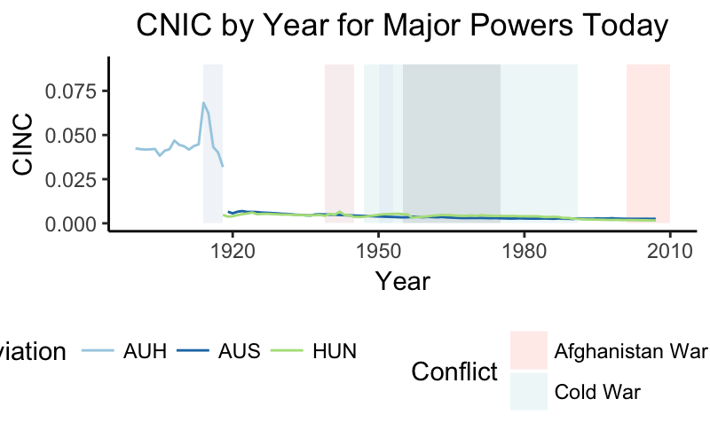

```r
test <- c("Austria-Hungary", "Austria", "Hungary")
test_ccode <- member_alliances$ccode[match(test, member_alliances$state_name)]
NMC_test <- filter(NMC, NMC$year %in% all_year)
NMC_test <- filter(NMC_test, NMC_test$ccode %in% test_ccode)
ggplot() +
  scale_x_continuous(name="Year") +
  scale_y_continuous(name="CINC") +
  labs(color ='Country Abbreviation')+
  geom_rect(data=d, mapping=aes(xmin=x1, xmax=x2, ymin=0, ymax=.09, fill=Conflict),alpha=0.15) +
  geom_line(data = NMC_test, aes(x = year, y = cinc, color = stateabb, group = stateabb)) +
  ggtitle("CNIC by Year for Major Powers Today") +
  theme_classic()+
  scale_fill_manual(values=c("salmon", "paleturquoise3", "lightsteelblue2", "lightsteelblue4", "lightsteelblue3", "pink3"))+
  scale_color_brewer(palette="Paired")+
  theme(plot.title = element_text(hjust = .5), legend.position = "bottom")
```